# RNotebooks - The Powerful Polyglot

Derek Slone-Zhen  
Wednesday, 12th April, 2017

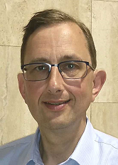

### The Origin And Ecosystem of RNotebooks

RNotebooks are part of the rich tapestry of Dynamic Documents that are available in the R ecosystem.

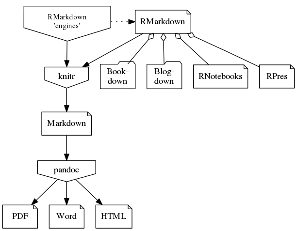

- [Markdown](http://daringfireball.net/projects/markdown/)
- [Markdown (Wikipedia)](https://en.wikipedia.org/wiki/Markdown)
- [RMarkdown](http://rmarkdown.rstudio.com/)
- [Pandoc](http://pandoc.org/)
- [RMarkdown Engines](https://yihui.name/knitr/demo/engines/)
- [Authoring RMarkdown Engines](http://rmarkdown.rstudio.com/authoring_knitr_engines.html)

### Markdown

Markdown was first released in 2004 by [John Gruber](https://en.wikipedia.org/wiki/John_Gruber) and [Aaron Swartz](https://en.wikipedia.org/wiki/Aaron_Swartz)

It was designed *firstly* to be human-readable, and *secondly* to be machine readable. Like YAML in the world of configuration files, Markdown was a response to the failed aspirations of XML to be a human-readable language.

It has become a de-facto standard in many environments, including GitHub, and is available either out-of-the box or as a plug in for many wikis and issue tracking systems.

[Quick Markdown Example](http://www.unexpected-vortices.com/sw/rippledoc/quick-markdown-example.html)

### RMarkdown

The ability to insert chunks of `R` code into vanilla Markdown.

Converted by the [`knitr`](https://github.com/yihui/knitr) package, created by [Yihui Xie](https://yihui.name/knitr/).

http://rmarkdown.rstudio.com/

RMarkdown and knitr have been working in this world for for over 4 years now.

## Example

Now, let me show you a plot:

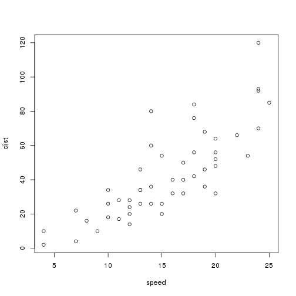

```r
plot(cars)
```

## RMarkdown Engines

## - the Polyglot Appears

### Supported Languages

In addition to `R` code, the `knitr` package support additional language engines, and allows you to add your own too. (We'll show that later.)

Most of the language you know and love are available (see right).

- **python**
- ruby
- **bash**
- **dot**
- awk
- **sql**
- Scala

### Execution Contexts & Persistence

However, unlike the `R` chunks, other language chunks get run in individual execution contexts. For `R` chunks, a single R session runs in the background and all `R` chunks are executed within that context, allowing for variable sharing and building up an environment. For other language, an interpreter (or other execution context) is launched for each chunk. This means that variables will have to be persisted by hand, typically through the file system.

Here's a quick example in Perl:

```perl
use strict;
my $a = 5;
while($a > 0) {
    print "Hello-#$a\n";
    $a--;
}
```

```
Hello-#5
Hello-#4
Hello-#3
Hello-#2
Hello-#1
```

## RMarkdown Engine Languages

### Python

Simply works.

I've had success with with [Anaconda](https://docs.continuum.io/anaconda/) and [babun](http://babun.github.io/) and [cygwin](https://www.cygwin.com/) should work too.

But, as for the much talked-about `feather` package that promises efficient file-inter-op between `R` and `python`; I totally failed to get that `python` module to install on Windows 10 Home. It requires a recent C++ compiler to build.

### Perl

Works, as seen above, but I used the [Strawberry Perl](http://strawberryperl.com/) as the babun version was getting linker errors.

(The truth is, I probably have too many cygwin-based tools all on my path, and the poor things are getting confused and intertwined in an unpleasant way!)

### bash

I use the bash in a babun distribution and it worked well. It's even tolerant of windows-style file names being passed to it. However, it's *not* tolerant of the full-stop that the RNotebook environment adds to the end of its file names ☹

So, getting bash to work on Windows take a little bit of trickery, especially since the style of invocation is different between the RNotebook environment and the knitr processor.

### bash for RNotenbooks - bash.bat

The following batch file proved to be the key for me:

```r
@rem bash.bat - a Windows batch file for invoking bash from RNotebooks
@echo off
SET BASH_PATH=C:\Users\Derek Slone-Zhen\.babun\cygwin\bin
PATH=%BASH_PATH%;%PATH%
"%BASH_PATH%\bash.exe" < "%~1"
```

### bash for knitr - engine.path

Together with an explicit engine.path for `bash` blocks to be used by `knitr`.  
(RNotebook processing engine appears to ignore theses.)

```r
knitr::opts_chunk$set(engine.path = list(
  bash = 'C:/Users/Derek Slone-Zhen/.babun/cygwin/bin/bash.exe'
))
```

### cmd

A code engine for Windows users!

```r
# Based on knitr::knit_engines$get('bash')
win_cmd <- function (options)
{
  cmd = 'C:/WINDOWS/system32/cmd.exe'
  out = if (options$eval) {
    message("running: ", cmd, " ", options$code)
    tmp_file <- tempfile(fileext = ".bat")
    writeLines(options$code, tmp_file)
    opts <- paste(options$engine.opts, "/c", tmp_file)
    tryCatch(system2(cmd, opts, stdout = TRUE, stderr = TRUE, env = options$engine.env),
             error = function(e) { if (!options$error) stop(e)
               paste("Error in running command", cmd, code)
             },
             finally = { file.remove(tmp_file) })
  } else ""
  if (!options$error && !is.null(attr(out, "status")))
    stop(paste(out, collapse = "\n"))
  knitr::engine_output(options, options$code, out)
}
knitr::knit_engines$set(cmd=win_cmd)
```

### dot (Graphviz)

[Graphviz](http://www.graphviz.org/) is an awesome tool for auto-magically laying out graphs.

The box th the right shows the “source code” for the first graph.

```dot
digraph {

    { rank="same"
      ordering= "out"
      "RMarkdown\n'engines'" [shape="invhouse", fontsize="12"]
      "RMarkdown" [shape="note"]
      "RMarkdown\n'engines'" -> RMarkdown [style="dotted", minlen="2" ]
    }

    knitr [shape="invhouse"]
    pandoc [shape="invhouse"]
    RMarkdown [shape="note"]
    Markdown [shape="note"]
    RMarkdown -> knitr -> Markdown -> pandoc
    "RMarkdown\n'engines'" -> knitr

    RMarkdown -> {
      "Book-\ndown" [shape="folder"]
      "Blog-\ndown" [shape="folder"]
      "RNotebooks" [shape="note"]
      "RPres"  [shape="note"]
    } [dir="back", arrowtail="odiamond"]

  pandoc ->  {
    node [shape="note"]
      "PDF"
      "Word"
      "HTML"
  }
}
```

## Beyond RMarkdown

### R Presentations

https://support.rstudio.com/hc/en-us/articles/200486468-Authoring-R-Presentations

## Multi-part Documents

### Bookdown

A system for authoring complete books, too large for a single document

- https://bookdown.org/yihui/bookdown/
- https://bookdown.org/

### Blogdown

Go on, take a guess!

> After much searching around, I found blogdown by Yihui Xie, the man who created Knitr. Blogdown uses Hugo, a blogging framework for static pages built using the Go language. One word of warning, blogdown is still under development, but I’ve tested it out and there have been minor issues, but most of it is because there is no documentation right now if you’re stuck.

[http://kevinfw.com/post/blogging-with-r-markdown/]

- https://github.com/rstudio/blogdown

## RNotebooks

### Why I'm a raving fan

- Interactive workbench for rapid prototyping
- Reproducible research
- Amenable to source control (git is the integrated into RSudio)
- Languange “neutrality”
  - pick the right / best / easiest / one-you-know langauge for the job
- Alows for embedded `sql` too
- Can also be knitted to HTML, PDF or Word
  - (PDF requires a LaTeX installation, typically MikTeX on windows.)

### Demo

Demo RNotebook available at  
https://github.com/dereksz/RMarkdown-SURF-2017

## If time permits...

### brew

`brew` is a templateing engine for `R`, much like PHP or T4 templates.

Lets just dive in and take a look …

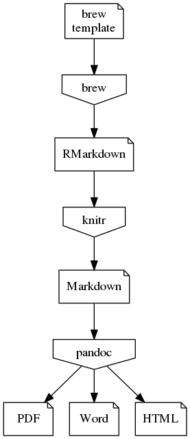